# Figure 1: Host-use ancestral state reconstruction

Naama Weksler & Marianna Karageorgi

2026-10-23

# 1. Overview

This notebook reconstructs the ancestral host use of Danaini along the butterfly phylogeny. It consumes two prepared inputs from Extended Data Figure 1 and does no raw-record processing of its own:

- `../input_data/Danaini_in_HOSTS.newick` — the Danaini species tree (tips are the species in the curated HOSTS dataset, including the outgroups *Mechanitis polymnia* and *Heliconius erato*).
- `../input_data/danaini_host_use_states.csv` — one host-use state per species, produced by Extended Data Fig. 1 (`5_build_host_matrix.Rmd`): the native-range *Asclepias* flag, the broader milkweed-clade flag, the host-use state coding, and each species’ ATPα genotype.

Because the per-species states are already curated there, this notebook only joins them onto the tree and runs a **three-state** host-use reconstruction — `none` / milkweed clade (Asclepiadoideae & Secamonoideae) / native-range *Asclepias* — and draws the full-tree figure, mirroring the analysis previously in `Blanca_HOSTS_milkweed_asclepias_ASR.Rmd`. The figure also carries an inner **ATPα tip strip** (the curated per-species ATPα genotype, with unsequenced taxa shown as “Unknown”), so host use and the ATPα functional state can be read side by side; the ATPα-focused figure, which reuses the node probabilities written here, lives in `../../Figure2/`.

Before reconstructing, internal branches with bootstrap support below `SUPPORT_CUTOFF` (70) are collapsed into polytomies, so the reconstruction does not assert ancestral states at splits the phylogeny does not resolve. The Mk model is refit on this collapsed tree and the node pies are drawn on it.

Node probabilities are written to `../output_data/`; figures to `../visuals/`.

```r
knitr::opts_chunk$set(warning = FALSE, message = FALSE)

library(tidyverse)
library(ape)
library(phytools)
library(ggtree)
library(ggnewscale)

dir.create("../output_data", showWarnings = FALSE)
dir.create("../visuals", showWarnings = FALSE)

clean_name <- function(x) {
  stringr::str_squish(stringr::str_replace_all(as.character(x), "_", " "))
}

# "Danaus plexippus" -> "D. plexippus" for tip labels
abbr_tip <- function(x) {
  x <- clean_name(x)
  vapply(x, function(z) {
    parts <- strsplit(z, " ")[[1]]
    if (length(parts) >= 2 && nchar(parts[1]) > 0)
      paste0(substr(parts[1], 1, 1), ". ", parts[2]) else z
  }, character(1))
}

# Collapse weakly-supported internal branches into polytomies. Node support
# (bootstrap, 0-100) rides on $node.label. We zero the branches subtending
# below-threshold nodes and let di2multi() merge them, which leaves every retained
# branch length — and therefore the Mk model fit in Section 4 — untouched. The root
# is never collapsed. Nodes with no / non-numeric support are left in place.
SUPPORT_CUTOFF <- 70

collapse_low_support <- function(phy, cutoff = SUPPORT_CUTOFF) {
  if (is.null(phy$node.label)) return(phy)
  supp     <- suppressWarnings(as.numeric(phy$node.label))
  internal <- (ape::Ntip(phy) + 1):(ape::Ntip(phy) + phy$Nnode)
  low      <- setdiff(internal[!is.na(supp) & supp < cutoff], ape::Ntip(phy) + 1)
  if (!length(low)) return(phy)
  phy$edge.length[phy$edge[, 2] %in% low] <- 0
  ape::di2multi(phy, tol = 1e-8)
}

# Shared palettes
full_palette <- c("none" = "grey90", "milkweed" = "#d7c0dd",
                  "asclepias" = "#65338f")
two_palette  <- c("none" = "grey90", "asclepias" = "#65338f")
# ATPα tip-strip palette and level order (matches Extended Data Fig. 1 / Figure 2,
# where QAN is the Heliconius genotype). Unsequenced tips are coded "Unknown" and
# share the grey of the "none" host-use state.
atpa_palette <- c("VSH" = "#ed1c2c", "VSN" = "#f36f21", "LSN" = "#fec12b",
                  "LAN" = "#3a6a9e", "QAN" = "grey30",
                  "Unknown" = unname(full_palette[["none"]]))
atpa_levels  <- c("VSH", "VSN", "LSN", "LAN", "QAN", "Unknown")
```

# 2. Read the tree and the per-species host-use states

Each tree tip is assigned its host-use state from `danaini_host_use_states.csv`. A tip that has **no row** in that table has no documented host record in the curated HOSTS dataset (here, *Anetia thirza*); following the Figure 1 convention it is coded `none` — no documented milkweed / *Asclepias* use.

```r
tree_asr <- ape::read.tree("../input_data/Danaini_in_HOSTS.newick")
tree_asr$tip.label <- clean_name(tree_asr$tip.label)

# Collapse internal branches with bootstrap support < SUPPORT_CUTOFF into
# polytomies before anything downstream, so the reference ordering, the Mk fit, and
# the node pies all describe the same reduced-resolution tree.
n_nodes_before <- tree_asr$Nnode
tree_asr <- collapse_low_support(tree_asr)
cat("Collapsed", n_nodes_before - tree_asr$Nnode,
    "internal node(s) with support <", SUPPORT_CUTOFF, "into polytomies; ",
    tree_asr$Nnode, "of", n_nodes_before, "internal nodes remain.\n")
```

```
## Collapsed 17 internal node(s) with support < 70 into polytomies;  38 of 55 internal nodes remain.
```

```r
# Orient the tree to the curated reference order used by the earlier reconstruction
# (and by Extended Data Fig. 1 / Figure 2) rather than ladderizing: rotate internal
# nodes so the tips read top-to-bottom in that order. Rotation changes only the
# display, not the topology or branch lengths. Heliconius erato is absent from the
# reference tree, so it is placed at the base alongside the other outgroups.
reference_tree <- ape::read.tree("../input_data/danaini_reference_order.newick")
reference_tree$tip.label <- clean_name(reference_tree$tip.label)
reference_order <- {
  d <- ggtree(reference_tree, ladderize = FALSE)$data
  d <- d[d$isTip, ]
  clean_name(d$label[order(d$y, decreasing = TRUE)])
}
reference_order <- c(reference_order, "Heliconius erato")
tree_asr <- ape::rotateConstr(
  tree_asr, rev(intersect(reference_order, tree_asr$tip.label))
)

states_raw <- read.csv(
  "../input_data/danaini_host_use_states.csv",
  stringsAsFactors = FALSE
) %>%
  mutate(butterfly_species = clean_name(butterfly_species))

# One row per tree tip; tips absent from the states table are coded "none".
host_states_tbl <- tibble(butterfly_species = tree_asr$tip.label) %>%
  left_join(states_raw, by = "butterfly_species") %>%
  mutate(
    has_milkweed         = tidyr::replace_na(as.logical(has_asclepiad_secamonoid), FALSE),
    has_asclepias_native = tidyr::replace_na(as.logical(has_asclepias_native), FALSE),
    host_use = case_when(
      has_asclepias_native ~ "asclepias",   # native-range Asclepias
      has_milkweed         ~ "milkweed",    # broader milkweed clade
      TRUE                 ~ "none"
    )
  )

cat("Tree tips:", length(tree_asr$tip.label), "\n")
```

```
## Tree tips: 56
```

```r
cat("Tips coded 'none' because absent from the states table:",
    paste(setdiff(tree_asr$tip.label, states_raw$butterfly_species),
          collapse = ", "), "\n")
```

```
## Tips coded 'none' because absent from the states table: Anetia thirza
```

# 3. Tip-strip helpers (host-use bars + ATPα strip)

```r
# Two host-use bars (milkweed-clade use, native-Asclepias use) on the shared
# three-level scale, for any (sub)tree.
host_bars_for <- function(tree_f) {
  host_states_tbl %>%
    filter(butterfly_species %in% tree_f$tip.label) %>%
    transmute(
      butterfly_species,
      milkweed_use  = factor(if_else(has_milkweed, "milkweed", "none"),
                             levels = c("none", "milkweed", "asclepias")),
      asclepias_use = factor(if_else(has_asclepias_native, "asclepias", "none"),
                             levels = c("none", "milkweed", "asclepias"))
    ) %>%
    column_to_rownames("butterfly_species") %>%
    { .[tree_f$tip.label, , drop = FALSE] }
}

# Species with a sequenced ATPα genotype (everything else stays unknown -> grey).
atpa_known_species <- states_raw %>%
  transmute(butterfly_species,
            atpa_state = dplyr::na_if(str_squish(atpa_state), "")) %>%
  filter(!is.na(atpa_state), atpa_state != "unknown")

# Inner ATPα strip (rownames = tips) for any (sub)tree; tips with no sequenced
# genotype are coded "Unknown" (drawn in the "none" grey), so the strip reads as
# continuous grey wherever a genotype is unknown.
atpa_strip_for <- function(tree_f) {
  tibble(butterfly_species = tree_f$tip.label) %>%
    left_join(atpa_known_species, by = "butterfly_species") %>%
    mutate(atpa_state = factor(tidyr::replace_na(atpa_state, "Unknown"),
                               levels = atpa_levels)) %>%
    column_to_rownames("butterfly_species") %>%
    { .[tree_f$tip.label, , drop = FALSE] }
}
```

# 4. Three-state ancestral state reconstruction

States: `none`, `milkweed` (any Asclepiadoideae / Secamonoideae genus), and `asclepias` (an *Asclepias* record whose butterfly’s native range overlaps *Asclepias*). Priority: native *Asclepias* > milkweed clade > none.

The transition model is selected by AIC among equal-rates (`ER`), symmetric (`SYM`), and all-rates-different (`ARD`) Mk models. The reconstruction uses **`SYM`**: it fits the data better than `ER` (lower AIC).

```r
states_three <- factor(
  setNames(host_states_tbl$host_use, host_states_tbl$butterfly_species)[tree_asr$tip.label],
  levels = c("none", "milkweed", "asclepias")
)
names(states_three) <- tree_asr$tip.label

cat("Three-state counts:\n"); print(table(states_three, useNA = "ifany"))
```

```
## Three-state counts:
```

```
## states_three
##      none  milkweed asclepias
##        23        28         5
```

```r
stopifnot(identical(names(states_three), tree_asr$tip.label),
          !any(is.na(states_three)))

# Model selection by AIC (lower = better).
mk_fits <- lapply(c(ER = "ER", SYM = "SYM", ARD = "ARD"),
                  function(m) phytools::fitMk(tree_asr, states_three, model = m))
cat("Mk transition-model AIC (lower = better):\n")
```

```
## Mk transition-model AIC (lower = better):
```

```r
print(round(sort(sapply(mk_fits, AIC)), 2))
```

```
##    SYM    ARD     ER
## 102.03 104.54 108.14
```

```r
# Use the symmetric model (best-supported, and free of ER's uniform-equilibrium
# bias toward the rare `asclepias` state).
fit_three <- mk_fits[["SYM"]]
anc_three <- phytools::ancr(fit_three)

asr_three <- as.data.frame(anc_three$ace)
asr_three$node <- (length(tree_asr$tip.label) + 1):
  (length(tree_asr$tip.label) + tree_asr$Nnode)
asr_three <- asr_three %>% mutate(milkweed_combined = milkweed + asclepias)

# Write the node probabilities with the milkweed-clade columns spelled out in full
# (the figures above keep the short "milkweed" key internally). The combined column
# is the milkweed clade plus native-range Asclepias.
asr_out <- asr_three %>%
  rename(`Asclepiadoideae & Secamonoideae` = milkweed,
         `Asclepiadoideae & Secamonoideae + Asclepias` = milkweed_combined)
write.csv(asr_out,
          "../output_data/host_use_milkweed_asclepias_ASR_node_probabilities.csv",
          row.names = FALSE)
head(asr_out)
```

```
##          none Asclepiadoideae & Secamonoideae    asclepias node
## 57 0.51526136                       0.4292407 5.549792e-02   57
## 58 0.55953724                       0.4189650 2.149775e-02   58
## 59 0.62887717                       0.3669073 4.215522e-03   59
## 60 0.56419337                       0.4314334 4.373237e-03   60
## 61 0.49443317                       0.4950100 1.055686e-02   61
## 62 0.04602469                       0.9539479 2.737471e-05   62
##    Asclepiadoideae & Secamonoideae + Asclepias
## 57                                   0.4847386
## 58                                   0.4404628
## 59                                   0.3711228
## 60                                   0.4358066
## 61                                   0.5055668
## 62                                   0.9539753
```

# 5. Full three-state figure (ATPα strip + two tip bars + node pies)

A cladogram with an inner ATPα-state strip (its own legend), two vertical host-use tip bars sharing one combined legend — a middle bar for milkweed-clade use and an outer bar for native *Asclepias* use — and three-state host-use ancestral pies on every internal node.

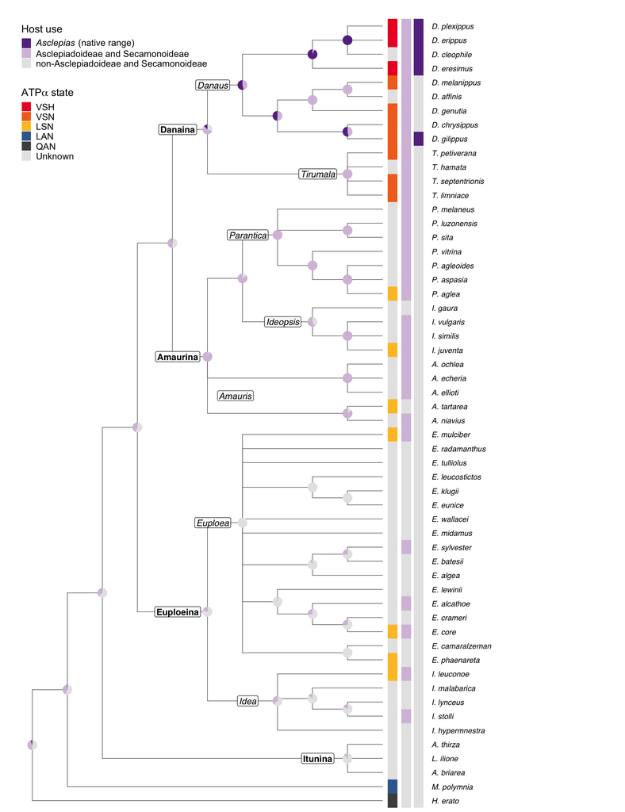

```r
bars <- host_bars_for(tree_asr)
milkweed_strip  <- bars[, "milkweed_use",  drop = FALSE]
asclepias_strip <- bars[, "asclepias_use", drop = FALSE]
atpa_strip      <- atpa_strip_for(tree_asr)

# Butterfly higher classification for the clade labels. Genus is the first word of
# each tip label; subtribe membership is set so each subtribe is monophyletic on this
# tree (Danaina = Danaus + Tirumala; Amaurina = Amauris + Ideopsis + Parantica, which
# form a clade here; Euploeina = Euploea + Idea; Itunina = the Neotropical Lycorea +
# Anetia). Each label is placed at the MRCA of its tips via getMRCA(), so the
# annotation tracks the tree after the low-support collapse and re-orientation rather
# than relying on fixed node numbers.
tip_genus <- sub(" .*", "", tree_asr$tip.label)
subtribe_tips <- list(
  Danaina   = tree_asr$tip.label[tip_genus %in% c("Danaus", "Tirumala")],
  Amaurina  = tree_asr$tip.label[tip_genus %in% c("Amauris", "Ideopsis", "Parantica")],
  Euploeina = tree_asr$tip.label[tip_genus %in% c("Euploea", "Idea")],
  Itunina   = tree_asr$tip.label[tip_genus %in% c("Lycorea", "Anetia")]
)
# Genera placed at their own MRCA. Amauris is handled separately below: the
# low-support collapse dissolved its crown into the Amaurina polytomy, so its MRCA
# coincides with the Amaurina node and it has no single crown node to label.
genus_tips <- list(
  Danaus    = tree_asr$tip.label[tip_genus %in% "Danaus"],
  Tirumala  = tree_asr$tip.label[tip_genus %in% "Tirumala"],
  Parantica = tree_asr$tip.label[tip_genus %in% "Parantica"],
  Ideopsis  = tree_asr$tip.label[tip_genus %in% "Ideopsis"],
  Euploea   = tree_asr$tip.label[tip_genus %in% "Euploea"],
  Idea      = tree_asr$tip.label[tip_genus %in% "Idea"]
)
df_node_labels <- dplyr::bind_rows(
  tibble::tibble(
    node       = vapply(subtribe_tips, function(t) ape::getMRCA(tree_asr, t), integer(1)),
    clade      = names(subtribe_tips),
    label_type = "subtribe"
  ),
  tibble::tibble(
    node       = vapply(genus_tips, function(t) ape::getMRCA(tree_asr, t), integer(1)),
    clade      = names(genus_tips),
    label_type = "genus"
  )
)

p <- ggtree(tree_asr, branch.length = "none", ladderize = FALSE,
            size = 0.3, color = "grey40") %<+% df_node_labels
tree_xmax <- max(p$data$x, na.rm = TRUE)

# Amauris genus label. Its crown collapsed into the Amaurina polytomy, so instead of a
# single node we place the label between the two Amauris-only branches that descend
# from that polytomy: vertically centred between them, and horizontally near where they
# diverge from the polytomy node (biased left so it sits on the branches rather than
# floating out toward the tips).
amaurina_node <- ape::getMRCA(tree_asr, subtribe_tips$Amaurina)
amaurina_kids <- tree_asr$edge[tree_asr$edge[, 1] == amaurina_node, 2]
amauris_kids  <- Filter(function(k) {
  kt <- if (k <= ape::Ntip(tree_asr)) tree_asr$tip.label[k]
        else ape::extract.clade(tree_asr, k)$tip.label
  all(sub(" .*", "", kt) == "Amauris")
}, amaurina_kids)
amaurina_x <- p$data$x[p$data$node == amaurina_node]
amauris_label <- tibble::tibble(
  x     = amaurina_x + 0.2 * (mean(p$data$x[p$data$node %in% amauris_kids]) - amaurina_x),
  y     = mean(p$data$y[p$data$node %in% amauris_kids]),
  clade = "Amauris"
)

# Inner strip: ATPα state (its own legend). Tips with no sequenced genotype are
# "Unknown" (grey). Offsets place the ATPα strip innermost, then the two host-use
# bars, then the tip labels.
p <- gheatmap(p, atpa_strip, offset = 0.01, width = 0.028,
              colnames = FALSE, color = NA) +
  scale_fill_manual(name = expression("ATP" * alpha * " state"),
                    values = atpa_palette, breaks = atpa_levels, drop = FALSE) +
  guides(fill = guide_legend(order = 2)) +
  ggnewscale::new_scale_fill()

# Both host-use bars share one fill scale -> one combined legend
p <- gheatmap(p, milkweed_strip, offset = tree_xmax * 0.04, width = 0.028,
              colnames = FALSE, color = NA)
p <- gheatmap(p, asclepias_strip, offset = tree_xmax * 0.075, width = 0.028,
              colnames = FALSE, color = NA) +
  scale_fill_manual(
    name   = "Host use",
    values = full_palette,
    breaks = c("asclepias", "milkweed", "none"),
    labels = c(expression(paste(italic("Asclepias"), " (native range)")),
               expression("Asclepiadoideae and Secamonoideae"),
               expression("non-Asclepiadoideae and Secamonoideae")),
    drop   = FALSE
  ) +
  guides(fill = guide_legend(order = 1)) +
  ggnewscale::new_scale_fill()

p <- p +
  geom_tiplab(aes(label = abbr_tip(label)), offset = tree_xmax * 0.135,
              size = 3.1, fontface = "italic", align = TRUE, linetype = 0) +
  xlim_tree(tree_xmax + 6)

# Butterfly clade labels on internal nodes, using the MRCA table attached above:
# subtribes in bold (white fill) and genera in italic (grey98 fill). Styling matches
# the earlier reconstruction; the subgenus layer is intentionally omitted.
p <- p +
  coord_cartesian(clip = "off") +
  geom_label2(
    aes(subset = !isTip & !is.na(clade) & label_type == "subtribe", label = clade),
    size = 3.6, label.size = 0.22, label.padding = grid::unit(0.16, "lines"),
    fill = "white", fontface = "bold", nudge_x = -0.85
  ) +
  geom_label2(
    aes(subset = !isTip & !is.na(clade) & label_type == "genus", label = clade),
    size = 3.6, label.size = 0.22, label.padding = grid::unit(0.16, "lines"),
    fill = "grey98", fontface = "italic", nudge_x = -0.85
  ) +
  # Amauris, placed manually between its two branches (see above).
  geom_label(
    data = amauris_label, aes(x = x, y = y, label = clade), inherit.aes = FALSE,
    size = 3.6, label.size = 0.22, label.padding = grid::unit(0.16, "lines"),
    fill = "grey98", fontface = "italic"
  )

pies <- nodepie(asr_three, cols = c("none", "milkweed", "asclepias"), alpha = 1)
pies <- lapply(pies, function(g)
  g + scale_fill_manual(values = full_palette) + theme(legend.position = "none"))

p_final <- inset(p, pies, width = 0.035, height = 0.035) +
  coord_cartesian(clip = "off") +
  theme(legend.position = c(0.02, 1.0), legend.justification = c(0, 1),
        legend.box = "vertical", legend.background = element_blank(),
        legend.key.size = unit(0.4, "cm"),
        legend.title = element_text(size = 12),
        legend.text = element_text(size = 10.5),
        plot.margin = margin(t = 22, r = 5, b = 5, l = 5))

p_final
```

```r
ggsave("../visuals/host_use_milkweed_asclepias_ASR.png",
       p_final, width = 10, height = 13)
```